# ANCOVA test for debate (engajamento no debate)

Geiser C. Challco geiser@alumni.usp.br

- Descriptive Statistics of Initial Data
- Checking of Assumptions
  - Assumption: Normality distribution of data
  - Assumption: Homogeneity of data distribution
- Computation of ANCOVA test and Pairwise Comparison
  - ANCOVA tests for one factor
  - ANCOVA tests for two factors
  - ANCOVA tests for grupo=“Experimental”
  - Pairwise comparisons for one factor
    - factor: **grupo**
    - factor: **genero**
    - factor: **idade**
    - factor: **zona.participante**
    - factor: **escola**
    - factor: **zona.escola**
  - Pairwise comparisons for two factors
    - factores: **grupo:genero**
    - factores: **grupo:idade**
    - factores: **grupo:zona.participante**
    - factores: **grupo:escola**
    - factores: **grupo:zona.escola**
  - Pairwise comparisons for grupo=“Experimental”
    - factores: **grupo=“Experimental”:monitor**
    - factores: **grupo=“Experimental”:monitor.genero**
    - factores: **grupo=“Experimental”:monitor.area**
    - factores: **grupo=“Experimental”:monitor.formacao**
    - factores: **grupo=“Experimental”:monitor.experiencia**

**NOTE**

- Teste ANCOVA para determinar se houve diferenças significativas em referência ao engajamento no debate (medido como estado de fluxo).
- ANCOVA test to determine whether there were significant differences in reference to engagement in debate (measured as flow state).

# Descriptive Statistics of Initial Data

| grupo | genero | idade | zona.participante | escola | zona.escola | variable | n | mean | median | min | max | sd | se | ci | iqr |
| --- | --- | --- | --- | --- | --- | --- | --- | --- | --- | --- | --- | --- | --- | --- | --- |
| Controle | F |  |  |  |  | fss.debate | 60 | 3.533 | 3.556 | 2.444 | 4.333 | 0.492 | 0.063 | 0.127 | 0.580 |
| Controle | M |  |  |  |  | fss.debate | 62 | 3.322 | 3.333 | 2.111 | 4.222 | 0.501 | 0.064 | 0.127 | 0.667 |
| Experimental | F |  |  |  |  | fss.debate | 56 | 3.658 | 3.611 | 2.111 | 4.750 | 0.554 | 0.074 | 0.148 | 0.722 |
| Experimental | M |  |  |  |  | fss.debate | 75 | 3.433 | 3.444 | 2.111 | 5.000 | 0.554 | 0.064 | 0.127 | 0.667 |
| Controle | F |  |  |  |  | dfs.debate | 60 | 3.481 | 3.556 | 2.333 | 4.556 | 0.542 | 0.070 | 0.140 | 0.795 |
| Controle | M |  |  |  |  | dfs.debate | 62 | 3.444 | 3.444 | 2.000 | 4.556 | 0.586 | 0.074 | 0.149 | 0.750 |
| Experimental | F |  |  |  |  | dfs.debate | 56 | 3.512 | 3.667 | 1.889 | 4.667 | 0.560 | 0.075 | 0.150 | 0.556 |
| Experimental | M |  |  |  |  | dfs.debate | 75 | 3.305 | 3.222 | 2.375 | 4.556 | 0.532 | 0.061 | 0.122 | 0.833 |
| Controle |  | 10y |  |  |  | fss.debate | 24 | 3.440 | 3.444 | 2.111 | 4.333 | 0.629 | 0.128 | 0.266 | 1.139 |
| Controle |  | 11y |  |  |  | fss.debate | 65 | 3.424 | 3.444 | 2.111 | 4.333 | 0.479 | 0.059 | 0.119 | 0.639 |
| Controle |  | 12y |  |  |  | fss.debate | 17 | 3.515 | 3.444 | 2.778 | 4.333 | 0.456 | 0.111 | 0.235 | 0.667 |
| Controle |  | 13y |  |  |  | fss.debate | 7 | 3.349 | 3.222 | 2.889 | 3.889 | 0.360 | 0.136 | 0.333 | 0.500 |
| Controle |  | 14y |  |  |  | fss.debate | 1 | 3.667 | 3.667 | 3.667 | 3.667 |  |  |  | 0.000 |
| Controle |  | 15y |  |  |  | fss.debate | 1 | 2.222 | 2.222 | 2.222 | 2.222 |  |  |  | 0.000 |
| Controle |  | 16y |  |  |  | fss.debate | 1 | 3.111 | 3.111 | 3.111 | 3.111 |  |  |  | 0.000 |
| Controle |  |  |  |  |  | fss.debate | 6 | 3.434 | 3.444 | 2.714 | 4.111 | 0.495 | 0.202 | 0.519 | 0.556 |
| Experimental |  | 10y |  |  |  | fss.debate | 24 | 3.519 | 3.444 | 2.556 | 4.444 | 0.497 | 0.101 | 0.210 | 0.694 |
| Experimental |  | 11y |  |  |  | fss.debate | 79 | 3.550 | 3.556 | 2.111 | 5.000 | 0.590 | 0.066 | 0.132 | 0.660 |
| Experimental |  | 12y |  |  |  | fss.debate | 16 | 3.653 | 3.667 | 2.667 | 4.556 | 0.511 | 0.128 | 0.273 | 0.500 |
| Experimental |  | 13y |  |  |  | fss.debate | 9 | 3.125 | 3.111 | 2.625 | 3.778 | 0.345 | 0.115 | 0.265 | 0.333 |
| Experimental |  | 14y |  |  |  | fss.debate | 1 | 4.667 | 4.667 | 4.667 | 4.667 |  |  |  | 0.000 |
| Experimental |  |  |  |  |  | fss.debate | 2 | 3.056 | 3.056 | 2.889 | 3.222 | 0.236 | 0.167 | 2.118 | 0.167 |
| Controle |  | 10y |  |  |  | dfs.debate | 24 | 3.513 | 3.556 | 2.444 | 4.556 | 0.538 | 0.110 | 0.227 | 0.611 |
| Controle |  | 11y |  |  |  | dfs.debate | 65 | 3.485 | 3.556 | 2.000 | 4.556 | 0.565 | 0.070 | 0.140 | 0.667 |
| Controle |  | 12y |  |  |  | dfs.debate | 17 | 3.533 | 3.444 | 2.778 | 4.500 | 0.533 | 0.129 | 0.274 | 0.667 |
| Controle |  | 13y |  |  |  | dfs.debate | 7 | 3.450 | 3.444 | 2.556 | 4.375 | 0.581 | 0.220 | 0.537 | 0.556 |
| Controle |  | 14y |  |  |  | dfs.debate | 1 | 2.556 | 2.556 | 2.556 | 2.556 |  |  |  | 0.000 |
| Controle |  | 15y |  |  |  | dfs.debate | 1 | 2.111 | 2.111 | 2.111 | 2.111 |  |  |  | 0.000 |
| Controle |  | 16y |  |  |  | dfs.debate | 1 | 3.556 | 3.556 | 3.556 | 3.556 |  |  |  | 0.000 |
| Controle |  |  |  |  |  | dfs.debate | 6 | 3.185 | 3.056 | 2.667 | 4.000 | 0.515 | 0.210 | 0.540 | 0.667 |
| Experimental |  | 10y |  |  |  | dfs.debate | 24 | 3.296 | 3.333 | 2.333 | 4.444 | 0.522 | 0.107 | 0.220 | 0.833 |
| Experimental |  | 11y |  |  |  | dfs.debate | 79 | 3.475 | 3.556 | 1.889 | 4.667 | 0.579 | 0.065 | 0.130 | 0.833 |
| Experimental |  | 12y |  |  |  | dfs.debate | 16 | 3.333 | 3.222 | 2.778 | 4.111 | 0.424 | 0.106 | 0.226 | 0.722 |
| Experimental |  | 13y |  |  |  | dfs.debate | 9 | 3.154 | 3.111 | 2.500 | 4.000 | 0.533 | 0.178 | 0.409 | 0.778 |
| Experimental |  | 14y |  |  |  | dfs.debate | 1 | 2.750 | 2.750 | 2.750 | 2.750 |  |  |  | 0.000 |
| Experimental |  |  |  |  |  | dfs.debate | 2 | 3.222 | 3.222 | 2.778 | 3.667 | 0.629 | 0.444 | 5.647 | 0.444 |
| Controle |  |  | Urbana |  |  | fss.debate | 51 | 3.443 | 3.375 | 2.111 | 4.333 | 0.525 | 0.073 | 0.148 | 0.604 |
| Controle |  |  | Rural |  |  | fss.debate | 43 | 3.364 | 3.444 | 2.111 | 4.333 | 0.523 | 0.080 | 0.161 | 0.667 |
| Controle |  |  |  |  |  | fss.debate | 28 | 3.488 | 3.646 | 2.556 | 4.222 | 0.446 | 0.084 | 0.173 | 0.583 |
| Experimental |  |  | Urbana |  |  | fss.debate | 49 | 3.586 | 3.556 | 2.625 | 4.778 | 0.513 | 0.073 | 0.147 | 0.556 |
| Experimental |  |  | Rural |  |  | fss.debate | 52 | 3.440 | 3.389 | 2.111 | 4.750 | 0.568 | 0.079 | 0.158 | 0.691 |
| Experimental |  |  |  |  |  | fss.debate | 30 | 3.589 | 3.611 | 2.111 | 5.000 | 0.628 | 0.115 | 0.234 | 0.833 |
| Controle |  |  | Urbana |  |  | dfs.debate | 51 | 3.365 | 3.444 | 2.000 | 4.500 | 0.628 | 0.088 | 0.177 | 0.833 |
| Controle |  |  | Rural |  |  | dfs.debate | 43 | 3.532 | 3.556 | 2.444 | 4.556 | 0.526 | 0.080 | 0.162 | 0.889 |
| Controle |  |  |  |  |  | dfs.debate | 28 | 3.531 | 3.500 | 2.778 | 4.556 | 0.476 | 0.090 | 0.185 | 0.556 |
| Experimental |  |  | Urbana |  |  | dfs.debate | 49 | 3.388 | 3.444 | 2.222 | 4.667 | 0.572 | 0.082 | 0.164 | 0.778 |
| Experimental |  |  | Rural |  |  | dfs.debate | 52 | 3.393 | 3.292 | 2.556 | 4.556 | 0.537 | 0.074 | 0.149 | 0.778 |
| Experimental |  |  |  |  |  | dfs.debate | 30 | 3.405 | 3.556 | 1.889 | 4.222 | 0.562 | 0.103 | 0.210 | 0.639 |
| Controle |  |  |  | E1 |  | fss.debate | 12 | 3.361 | 3.333 | 2.222 | 4.333 | 0.596 | 0.172 | 0.379 | 0.778 |
| Controle |  |  |  | E2 |  | fss.debate | 22 | 3.363 | 3.333 | 2.111 | 4.333 | 0.610 | 0.130 | 0.271 | 0.851 |
| Controle |  |  |  | E3 |  | fss.debate | 15 | 3.421 | 3.444 | 2.778 | 4.333 | 0.417 | 0.108 | 0.231 | 0.389 |
| Controle |  |  |  | E4 |  | fss.debate | 15 | 3.393 | 3.222 | 2.778 | 4.333 | 0.482 | 0.125 | 0.267 | 0.778 |
| Controle |  |  |  | E5 |  | fss.debate | 47 | 3.474 | 3.444 | 2.111 | 4.333 | 0.510 | 0.074 | 0.150 | 0.604 |
| Controle |  |  |  | E6 |  | fss.debate | 11 | 3.465 | 3.667 | 2.556 | 3.778 | 0.358 | 0.108 | 0.240 | 0.333 |
| Experimental |  |  |  | E1 |  | fss.debate | 10 | 3.779 | 3.611 | 2.500 | 4.667 | 0.645 | 0.204 | 0.461 | 0.608 |
| Experimental |  |  |  | E2 |  | fss.debate | 26 | 3.427 | 3.389 | 2.625 | 4.222 | 0.424 | 0.083 | 0.171 | 0.528 |
| Experimental |  |  |  | E3 |  | fss.debate | 15 | 3.231 | 3.333 | 2.111 | 4.222 | 0.576 | 0.149 | 0.319 | 0.611 |
| Experimental |  |  |  | E4 |  | fss.debate | 14 | 3.714 | 3.653 | 2.778 | 4.750 | 0.572 | 0.153 | 0.330 | 0.653 |
| Experimental |  |  |  | E5 |  | fss.debate | 53 | 3.504 | 3.556 | 2.111 | 5.000 | 0.580 | 0.080 | 0.160 | 0.778 |
| Experimental |  |  |  | E6 |  | fss.debate | 13 | 3.786 | 3.889 | 3.111 | 4.444 | 0.496 | 0.138 | 0.300 | 0.778 |
| Controle |  |  |  | E1 |  | dfs.debate | 12 | 3.139 | 3.333 | 2.111 | 4.111 | 0.545 | 0.157 | 0.346 | 0.611 |
| Controle |  |  |  | E2 |  | dfs.debate | 22 | 3.505 | 3.556 | 2.375 | 4.444 | 0.476 | 0.102 | 0.211 | 0.556 |
| Controle |  |  |  | E3 |  | dfs.debate | 15 | 3.643 | 3.556 | 2.778 | 4.556 | 0.555 | 0.143 | 0.308 | 0.778 |
| Controle |  |  |  | E4 |  | dfs.debate | 15 | 3.403 | 3.556 | 2.111 | 4.375 | 0.638 | 0.165 | 0.353 | 0.556 |
| Controle |  |  |  | E5 |  | dfs.debate | 47 | 3.476 | 3.556 | 2.000 | 4.556 | 0.611 | 0.089 | 0.179 | 0.944 |
| Controle |  |  |  | E6 |  | dfs.debate | 11 | 3.505 | 3.444 | 2.778 | 4.111 | 0.349 | 0.105 | 0.235 | 0.278 |
| Experimental |  |  |  | E1 |  | dfs.debate | 10 | 3.179 | 3.222 | 2.375 | 3.778 | 0.417 | 0.132 | 0.298 | 0.500 |
| Experimental |  |  |  | E2 |  | dfs.debate | 26 | 3.461 | 3.444 | 2.500 | 4.667 | 0.540 | 0.106 | 0.218 | 0.750 |
| Experimental |  |  |  | E3 |  | dfs.debate | 15 | 3.496 | 3.778 | 2.556 | 4.556 | 0.696 | 0.180 | 0.386 | 1.000 |
| Experimental |  |  |  | E4 |  | dfs.debate | 14 | 3.464 | 3.389 | 2.889 | 4.500 | 0.460 | 0.123 | 0.266 | 0.694 |
| Experimental |  |  |  | E5 |  | dfs.debate | 53 | 3.330 | 3.333 | 1.889 | 4.222 | 0.587 | 0.081 | 0.162 | 0.889 |
| Experimental |  |  |  | E6 |  | dfs.debate | 13 | 3.491 | 3.667 | 2.667 | 4.111 | 0.421 | 0.117 | 0.254 | 0.556 |
| Controle |  |  |  |  | Urbana | fss.debate | 81 | 3.427 | 3.444 | 2.111 | 4.333 | 0.547 | 0.061 | 0.121 | 0.667 |
| Controle |  |  |  |  | Rural | fss.debate | 41 | 3.422 | 3.444 | 2.556 | 4.333 | 0.418 | 0.065 | 0.132 | 0.556 |
| Experimental |  |  |  |  | Urbana | fss.debate | 89 | 3.512 | 3.556 | 2.111 | 5.000 | 0.550 | 0.058 | 0.116 | 0.667 |
| Experimental |  |  |  |  | Rural | fss.debate | 42 | 3.564 | 3.528 | 2.111 | 4.750 | 0.594 | 0.092 | 0.185 | 0.774 |
| Controle |  |  |  |  | Urbana | dfs.debate | 81 | 3.434 | 3.444 | 2.000 | 4.556 | 0.575 | 0.064 | 0.127 | 0.889 |
| Controle |  |  |  |  | Rural | dfs.debate | 41 | 3.518 | 3.556 | 2.111 | 4.556 | 0.540 | 0.084 | 0.171 | 0.667 |
| Experimental |  |  |  |  | Urbana | dfs.debate | 89 | 3.351 | 3.444 | 1.889 | 4.667 | 0.558 | 0.059 | 0.118 | 0.889 |
| Experimental |  |  |  |  | Rural | dfs.debate | 42 | 3.484 | 3.611 | 2.556 | 4.556 | 0.533 | 0.082 | 0.166 | 0.792 |

# Checking of Assumptions

## Assumption: Normality distribution of data

| var | n | skewness | kurtosis | symmetry | statistic | method | p | p.signif | normality |
| --- | --- | --- | --- | --- | --- | --- | --- | --- | --- |
| fss.debate | 253 | 0.0864540 | 0.0235729 | YES | 0.4751693 | D’Agostino | 0.7885301 | ns | - |
| fss.debate | 245 | -0.0244359 | 0.2034209 | YES | 0.8543179 | D’Agostino | 0.6523598 | ns | - |
| fss.debate | 195 | 0.2215811 | 0.0126754 | YES | 1.8372674 | D’Agostino | 0.3990639 | ns | QQ |
| fss.debate | 253 | 0.0540845 | -0.0432749 | YES | 0.1540031 | D’Agostino | 0.9258884 | ns | - |
| fss.debate | 253 | 0.0721635 | 0.0289832 | YES | 0.3870111 | D’Agostino | 0.8240653 | ns | - |

## Assumption: Homogeneity of data distribution

| var | method | formula | n | DFn.df1 | DFd.df2 | statistic | p | p.signif |
| --- | --- | --- | --- | --- | --- | --- | --- | --- |
| fss.debate | Levene’s test | `.res`~`grupo`*`genero` | 253 | 3 | 249 | 0.7496590 | 0.5234572 | ns |
| fss.debate | Anova’s slopes | `.res`~`grupo`*`genero` | 253 | 3 | 245 | 1.0510000 | 0.3710000 | ns |
| fss.debate | Levene’s test | `.res`~`grupo`*`idade` | 245 | 11 | 233 | 1.3600121 | 0.1929457 | ns |
| fss.debate | Anova’s slopes | `.res`~`grupo`*`idade` | 245 | 7 | 225 | 0.4530000 | 0.8670000 | ns |
| fss.debate | Levene’s test | `.res`~`grupo`*`zona.participante` | 195 | 3 | 191 | 0.7552954 | 0.5205315 | ns |
| fss.debate | Anova’s slopes | `.res`~`grupo`*`zona.participante` | 195 | 3 | 187 | 0.7770000 | 0.5080000 | ns |
| fss.debate | Levene’s test | `.res`~`grupo`*`escola` | 253 | 11 | 241 | 0.6647433 | 0.7711715 | ns |
| fss.debate | Anova’s slopes | `.res`~`grupo`*`escola` | 253 | 11 | 229 | 1.4520000 | 0.1510000 | ns |
| fss.debate | Levene’s test | `.res`~`grupo`*`zona.escola` | 253 | 3 | 249 | 0.8985271 | 0.4425323 | ns |
| fss.debate | Anova’s slopes | `.res`~`grupo`*`zona.escola` | 253 | 3 | 245 | 2.1080000 | 0.1000000 | ns |

# Computation of ANCOVA test and Pairwise Comparison

## ANCOVA tests for one factor

|  | Effect | DFn | DFd | SSn | SSd | F | p | ges | p<.05 |
| --- | --- | --- | --- | --- | --- | --- | --- | --- | --- |
| 1 | dfs.debate | 1 | 250 | 10.757 | 61.361 | 43.828 | <0.001 | 0.149 | * |
| 2 | grupo | 1 | 250 | 1.040 | 61.361 | 4.237 | 0.041 | 0.017 | * |
| 4 | genero | 1 | 250 | 1.705 | 60.696 | 7.024 | 0.009 | 0.027 | * |
| 6 | idade | 6 | 237 | 3.654 | 57.143 | 2.526 | 0.022 | 0.060 | * |
| 8 | zona.participante | 1 | 192 | 0.867 | 48.247 | 3.449 | 0.065 | 0.018 |  |
| 10 | escola | 5 | 246 | 3.050 | 59.351 | 2.529 | 0.03 | 0.049 | * |
| 12 | zona.escola | 1 | 250 | 0.018 | 62.383 | 0.074 | 0.786 | 0.000 |  |

## ANCOVA tests for two factors

|  | Effect | DFn | DFd | SSn | SSd | F | p | ges | p<.05 |
| --- | --- | --- | --- | --- | --- | --- | --- | --- | --- |
| 1 | dfs.debate | 1 | 248 | 9.683 | 59.460 | 40.388 | <0.001 | 0.140 | * |
| 4 | grupo:genero | 1 | 248 | 0.032 | 59.460 | 0.133 | 0.715 | 0.001 |  |
| 8 | grupo:idade | 4 | 232 | 0.612 | 55.383 | 0.641 | 0.634 | 0.011 |  |
| 12 | grupo:zona.participante | 1 | 190 | 0.002 | 47.438 | 0.008 | 0.93 | 0.000 |  |
| 16 | grupo:escola | 5 | 240 | 1.430 | 56.790 | 1.208 | 0.306 | 0.025 |  |
| 20 | grupo:zona.escola | 1 | 248 | 0.020 | 61.325 | 0.082 | 0.775 | 0.000 |  |

## ANCOVA tests for grupo=“Experimental”

|  | Effect | DFn | DFd | SSn | SSd | F | p | ges | p<.05 |
| --- | --- | --- | --- | --- | --- | --- | --- | --- | --- |
| 1 | dfs.debate | 1 | 111 | 5.856 | 27.343 | 23.771 | <0.001 | 0.176 | * |
| 2 | monitor | 9 | 111 | 5.839 | 27.343 | 2.634 | 0.008 | 0.176 | * |
| 4 | monitor.genero | 1 | 119 | 0.925 | 32.257 | 3.412 | 0.067 | 0.028 |  |
| 6 | monitor.area | 8 | 112 | 5.416 | 27.766 | 2.731 | 0.009 | 0.163 | * |
| 8 | monitor.formacao | 2 | 118 | 0.362 | 32.820 | 0.650 | 0.524 | 0.011 |  |
| 10 | monitor.experiencia | 1 | 119 | 0.000 | 33.182 | 0.001 | 0.975 | 0.000 |  |

## Pairwise comparisons for one factor

### factor: **grupo**

| var | grupo | n | M (pre) | SE (pre) | M (unadj) | SE (unadj) | M (adj) | SE (adj) |
| --- | --- | --- | --- | --- | --- | --- | --- | --- |
| fss.debate | Controle | 122 | 3.462 | 0.051 | 3.426 | 0.046 | 3.413 | 0.045 |
| fss.debate | Experimental | 131 | 3.394 | 0.048 | 3.529 | 0.049 | 3.541 | 0.043 |

| .y. | group1 | group2 | estimate | conf.low | conf.high | se | statistic | p | p.adj | p.adj.signif |
| --- | --- | --- | --- | --- | --- | --- | --- | --- | --- | --- |
| fss.debate | Controle | Experimental | -0.129 | -0.252 | -0.006 | 0.062 | -2.058 | 0.041 | 0.041 | * |
| dfs.debate | Controle | Experimental | 0.068 | -0.070 | 0.206 | 0.070 | 0.976 | 0.330 | 0.330 | ns |

| .y. | grupo | group1 | group2 | estimate | conf.low | conf.high | se | statistic | p | p.adj | p.adj.signif |
| --- | --- | --- | --- | --- | --- | --- | --- | --- | --- | --- | --- |
| flow.debate | Controle | pre | pos | 0.036 | -0.101 | 0.174 | 0.070 | 0.520 | 0.603 | 0.603 | ns |
| flow.debate | Experimental | pre | pos | -0.135 | -0.268 | -0.002 | 0.068 | -2.001 | 0.046 | 0.046 | * |

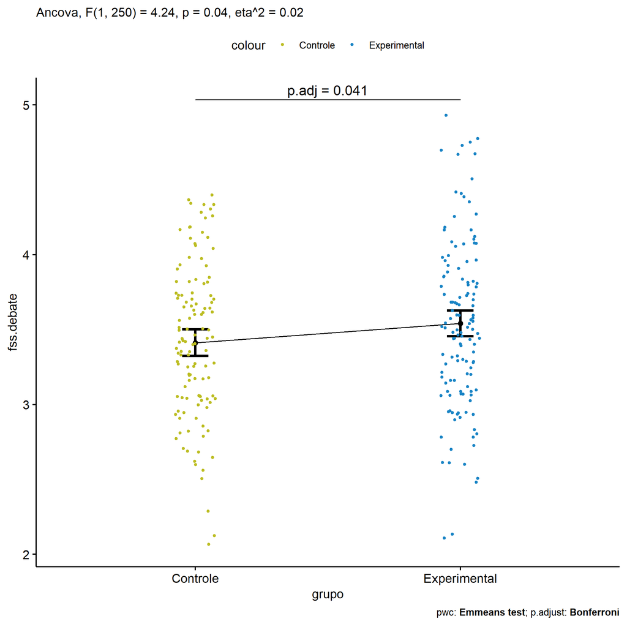

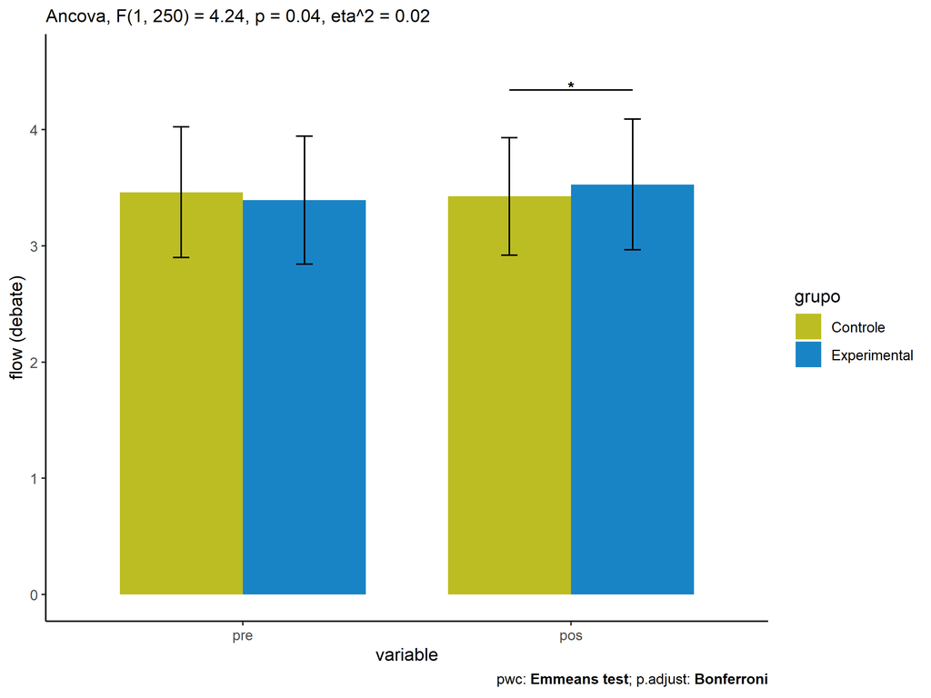

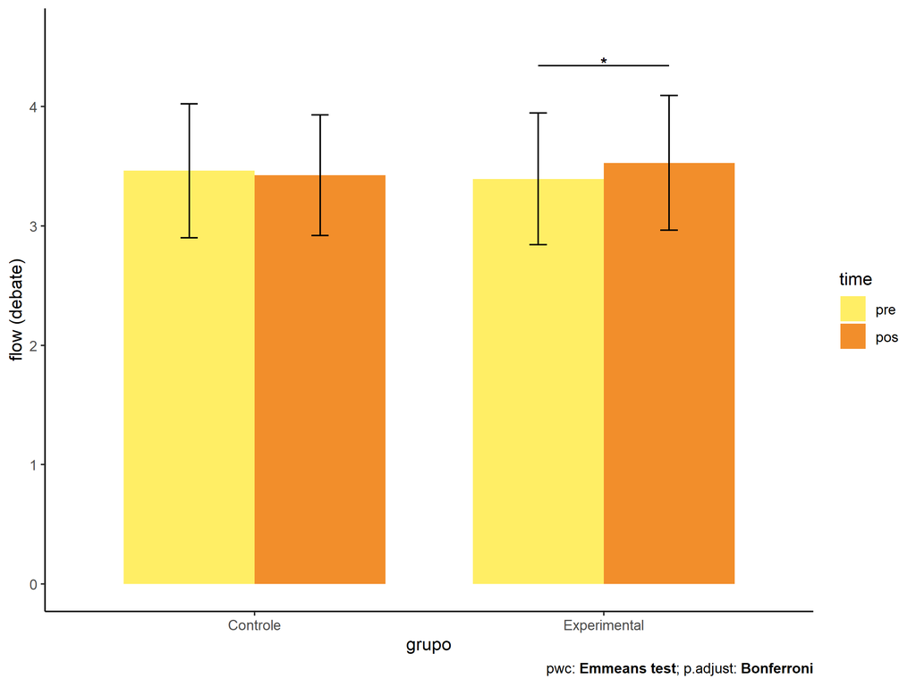

### factor: **genero**

| var | genero | n | M (pre) | SE (pre) | M (unadj) | SE (unadj) | M (adj) | SE (adj) |
| --- | --- | --- | --- | --- | --- | --- | --- | --- |
| fss.debate | F | 116 | 3.496 | 0.051 | 3.593 | 0.049 | 3.569 | 0.046 |
| fss.debate | M | 137 | 3.368 | 0.048 | 3.383 | 0.045 | 3.403 | 0.042 |

| .y. | group1 | group2 | estimate | conf.low | conf.high | se | statistic | p | p.adj | p.adj.signif |
| --- | --- | --- | --- | --- | --- | --- | --- | --- | --- | --- |
| fss.debate | F | M | 0.166 | 0.043 | 0.289 | 0.063 | 2.650 | 0.009 | 0.009 | ** |
| dfs.debate | F | M | 0.128 | -0.010 | 0.266 | 0.070 | 1.832 | 0.068 | 0.068 | ns |

| .y. | genero | group1 | group2 | estimate | conf.low | conf.high | se | statistic | p | p.adj | p.adj.signif |
| --- | --- | --- | --- | --- | --- | --- | --- | --- | --- | --- | --- |
| flow.debate | F | pre | pos | -0.097 | -0.237 | 0.043 | 0.071 | -1.364 | 0.173 | 0.173 | ns |
| flow.debate | M | pre | pos | -0.015 | -0.143 | 0.114 | 0.065 | -0.225 | 0.822 | 0.822 | ns |

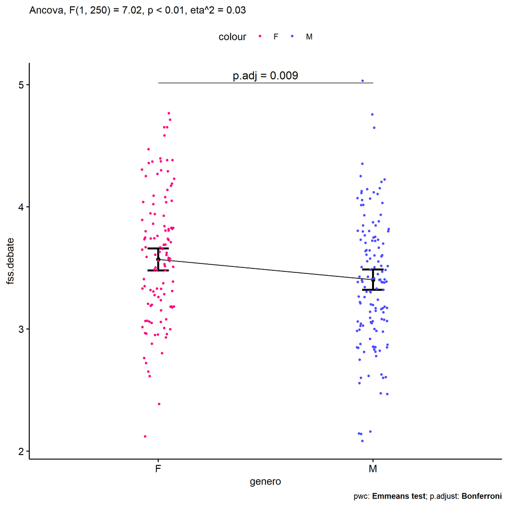

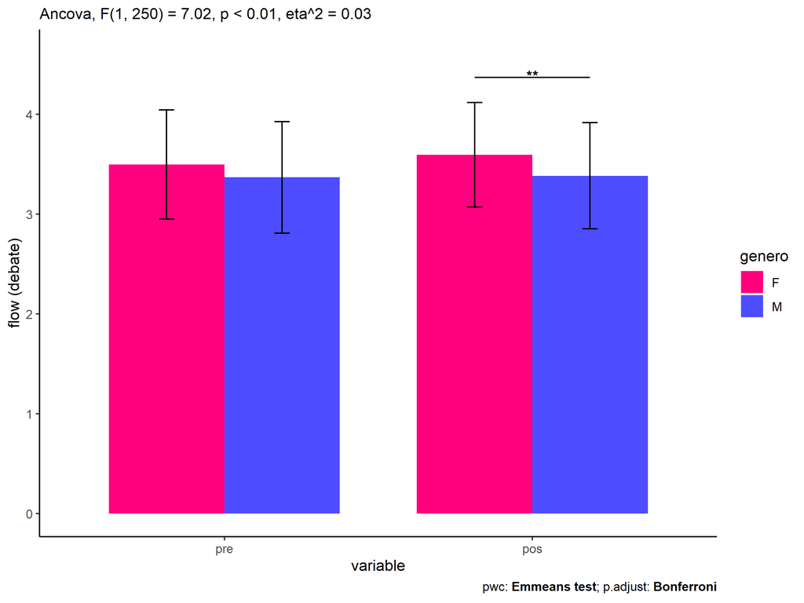

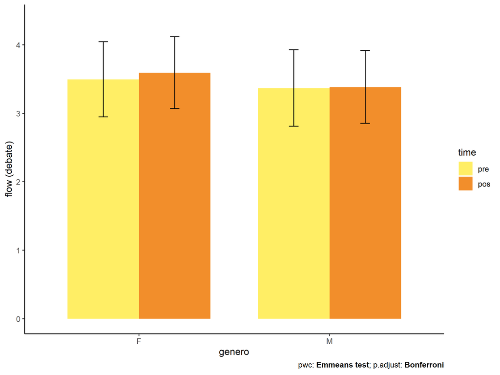

### factor: **idade**

| var | idade | n | M (pre) | SE (pre) | M (unadj) | SE (unadj) | M (adj) | SE (adj) |
| --- | --- | --- | --- | --- | --- | --- | --- | --- |
| fss.debate | 10y | 48 | 3.405 | 0.077 | 3.479 | 0.081 | 3.495 | 0.071 |
| fss.debate | 11y | 144 | 3.480 | 0.048 | 3.493 | 0.045 | 3.481 | 0.041 |
| fss.debate | 12y | 33 | 3.436 | 0.085 | 3.582 | 0.084 | 3.585 | 0.085 |
| fss.debate | 13y | 16 | 3.284 | 0.139 | 3.223 | 0.090 | 3.283 | 0.123 |

| .y. | group1 | group2 | estimate | conf.low | conf.high | se | statistic | p | p.adj | p.adj.signif |
| --- | --- | --- | --- | --- | --- | --- | --- | --- | --- | --- |
| fss.debate | 10y | 11y | 0.014 | -0.147 | 0.175 | 0.082 | 0.168 | 0.867 | 1.000 | ns |
| fss.debate | 10y | 12y | -0.091 | -0.309 | 0.128 | 0.111 | -0.817 | 0.415 | 1.000 | ns |
| fss.debate | 10y | 13y | 0.212 | -0.067 | 0.491 | 0.142 | 1.495 | 0.136 | 0.817 | ns |
| fss.debate | 11y | 12y | -0.104 | -0.291 | 0.082 | 0.095 | -1.102 | 0.271 | 1.000 | ns |
| fss.debate | 11y | 13y | 0.198 | -0.057 | 0.454 | 0.130 | 1.528 | 0.128 | 0.768 | ns |
| fss.debate | 12y | 13y | 0.302 | 0.008 | 0.597 | 0.150 | 2.022 | 0.044 | 0.266 | ns |
| dfs.debate | 10y | 11y | -0.075 | -0.256 | 0.106 | 0.092 | -0.817 | 0.415 | 1.000 | ns |
| dfs.debate | 10y | 12y | -0.032 | -0.278 | 0.215 | 0.125 | -0.252 | 0.801 | 1.000 | ns |
| dfs.debate | 10y | 13y | 0.121 | -0.193 | 0.435 | 0.159 | 0.757 | 0.450 | 1.000 | ns |
| dfs.debate | 11y | 12y | 0.044 | -0.166 | 0.254 | 0.107 | 0.410 | 0.683 | 1.000 | ns |
| dfs.debate | 11y | 13y | 0.196 | -0.091 | 0.483 | 0.146 | 1.346 | 0.180 | 1.000 | ns |
| dfs.debate | 12y | 13y | 0.152 | -0.179 | 0.484 | 0.168 | 0.905 | 0.367 | 1.000 | ns |

| .y. | idade | group1 | group2 | estimate | conf.low | conf.high | se | statistic | p | p.adj | p.adj.signif |
| --- | --- | --- | --- | --- | --- | --- | --- | --- | --- | --- | --- |
| flow.debate | 10y | pre | pos | -0.075 | -0.292 | 0.142 | 0.110 | -0.678 | 0.498 | 0.498 | ns |
| flow.debate | 11y | pre | pos | -0.014 | -0.139 | 0.112 | 0.064 | -0.216 | 0.829 | 0.829 | ns |
| flow.debate | 12y | pre | pos | -0.146 | -0.407 | 0.116 | 0.133 | -1.093 | 0.275 | 0.275 | ns |
| flow.debate | 13y | pre | pos | 0.061 | -0.315 | 0.437 | 0.191 | 0.318 | 0.751 | 0.751 | ns |

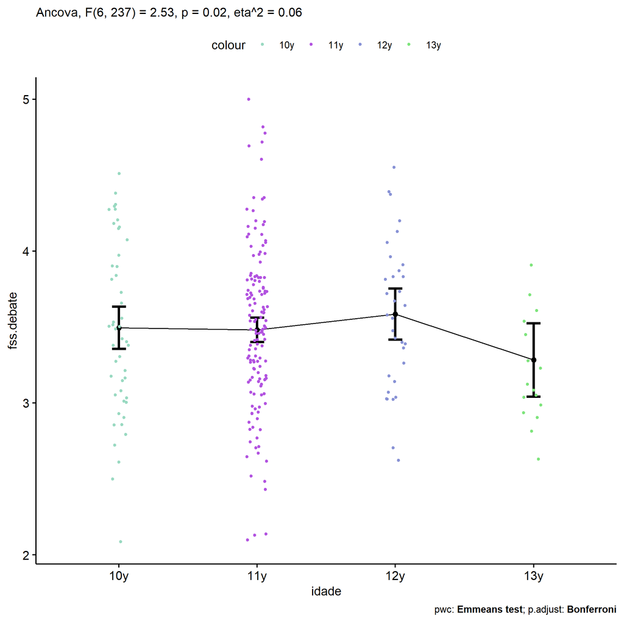

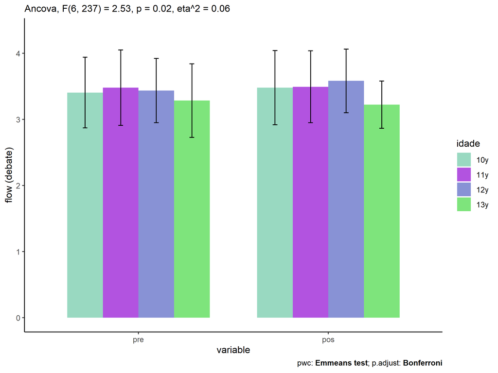

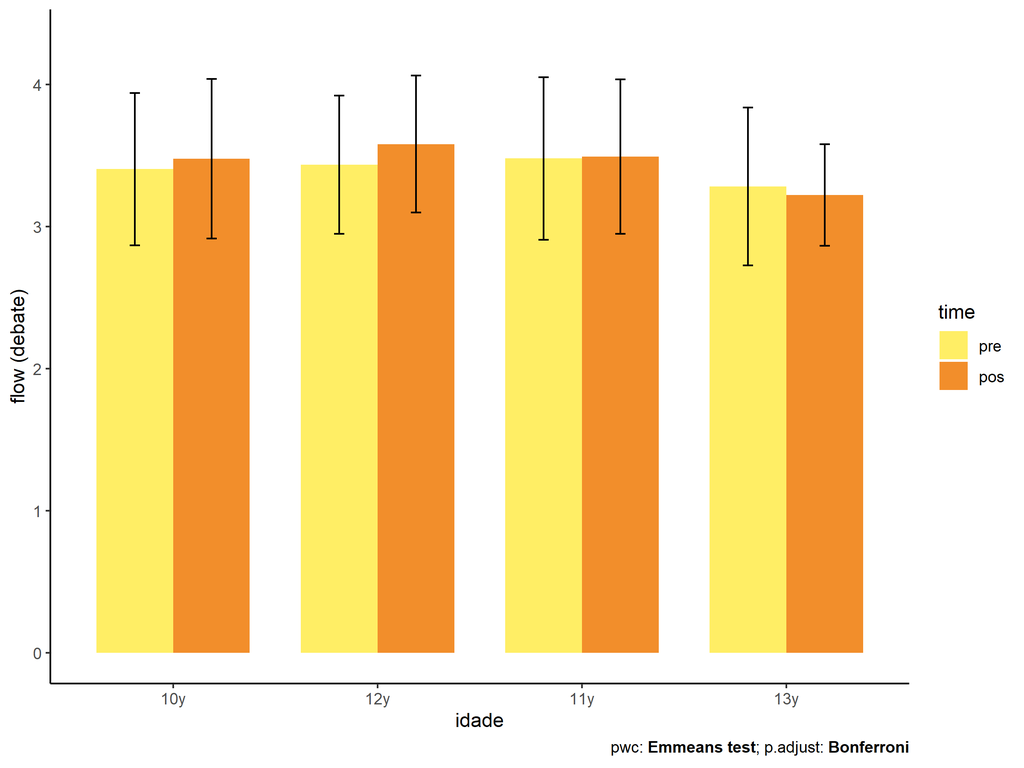

### factor: **zona.participante**

| var | zona.participante | n | M (pre) | SE (pre) | M (unadj) | SE (unadj) | M (adj) | SE (adj) |
| --- | --- | --- | --- | --- | --- | --- | --- | --- |
| fss.debate | Rural | 95 | 3.456 | 0.055 | 3.406 | 0.056 | 3.392 | 0.051 |
| fss.debate | Urbana | 100 | 3.376 | 0.060 | 3.513 | 0.052 | 3.526 | 0.050 |

| .y. | group1 | group2 | estimate | conf.low | conf.high | se | statistic | p | p.adj | p.adj.signif |
| --- | --- | --- | --- | --- | --- | --- | --- | --- | --- | --- |
| fss.debate | Urbana | Rural | 0.134 | -0.008 | 0.276 | 0.072 | 1.857 | 0.065 | 0.065 | ns |
| dfs.debate | Urbana | Rural | -0.079 | -0.240 | 0.081 | 0.081 | -0.976 | 0.331 | 0.331 | ns |

| .y. | zona.participante | group1 | group2 | estimate | conf.low | conf.high | se | statistic | p | p.adj | p.adj.signif |
| --- | --- | --- | --- | --- | --- | --- | --- | --- | --- | --- | --- |
| flow.debate | Urbana | pre | pos | -0.137 | -0.290 | 0.016 | 0.078 | -1.757 | 0.080 | 0.080 | ns |
| flow.debate | Rural | pre | pos | 0.050 | -0.107 | 0.207 | 0.080 | 0.625 | 0.532 | 0.532 | ns |

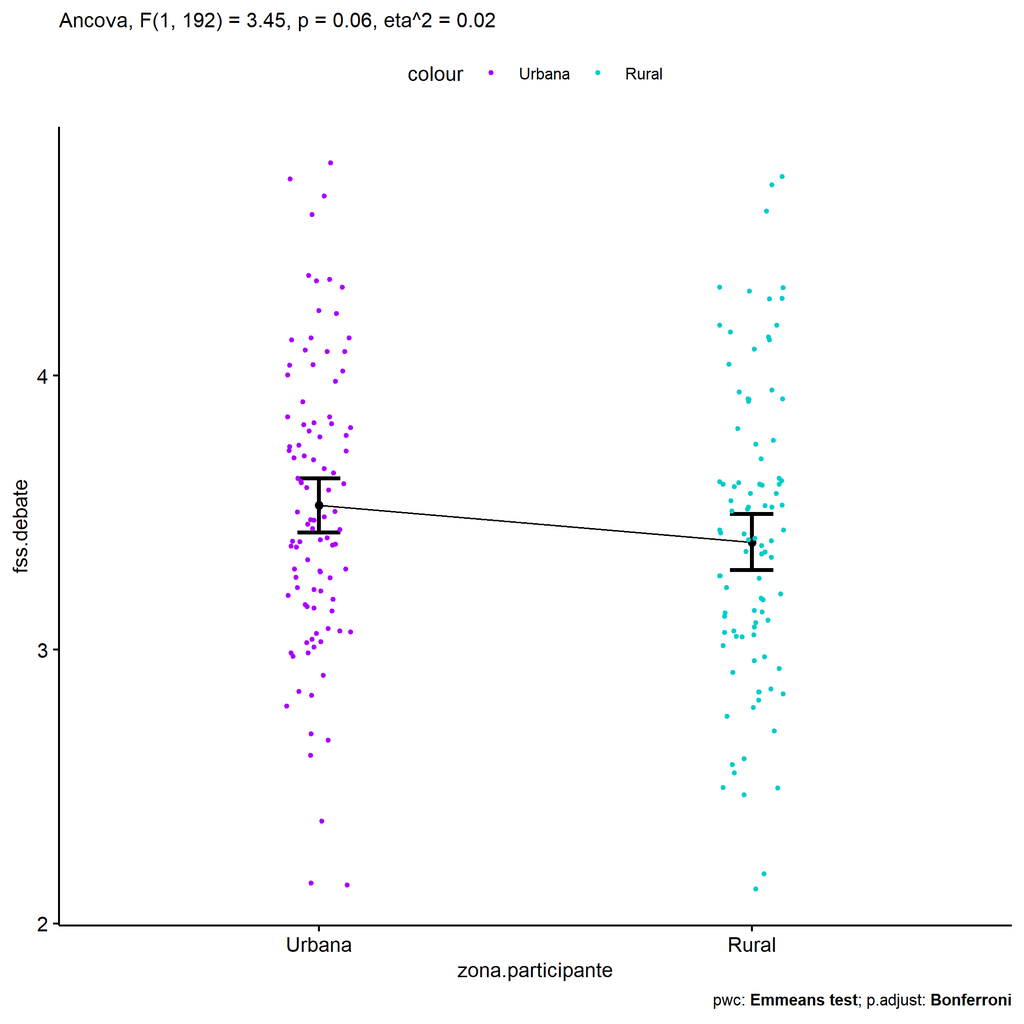

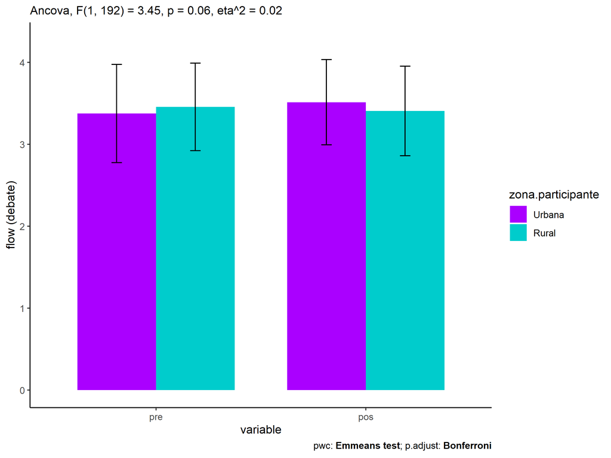

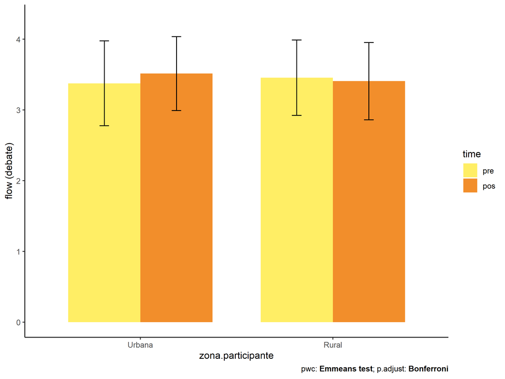

### factor: **escola**

| var | escola | n | M (pre) | SE (pre) | M (unadj) | SE (unadj) | M (adj) | SE (adj) |
| --- | --- | --- | --- | --- | --- | --- | --- | --- |
| fss.debate | E1 | 22 | 3.157 | 0.102 | 3.551 | 0.136 | 3.656 | 0.106 |
| fss.debate | E2 | 48 | 3.481 | 0.073 | 3.398 | 0.074 | 3.376 | 0.071 |
| fss.debate | E3 | 30 | 3.569 | 0.114 | 3.326 | 0.092 | 3.270 | 0.090 |
| fss.debate | E4 | 29 | 3.432 | 0.102 | 3.548 | 0.101 | 3.546 | 0.091 |
| fss.debate | E5 | 100 | 3.398 | 0.060 | 3.490 | 0.055 | 3.501 | 0.049 |
| fss.debate | E6 | 24 | 3.498 | 0.078 | 3.639 | 0.094 | 3.611 | 0.100 |

| .y. | group1 | group2 | estimate | conf.low | conf.high | se | statistic | p | p.adj | p.adj.signif |
| --- | --- | --- | --- | --- | --- | --- | --- | --- | --- | --- |
| fss.debate | E1 | E2 | 0.280 | 0.028 | 0.532 | 0.128 | 2.192 | 0.029 | 0.440 | ns |
| fss.debate | E1 | E3 | 0.386 | 0.111 | 0.662 | 0.140 | 2.763 | 0.006 | 0.093 | ns |
| fss.debate | E1 | E4 | 0.111 | -0.164 | 0.386 | 0.140 | 0.793 | 0.429 | 1.000 | ns |
| fss.debate | E1 | E5 | 0.155 | -0.074 | 0.385 | 0.116 | 1.333 | 0.184 | 1.000 | ns |
| fss.debate | E1 | E6 | 0.045 | -0.243 | 0.333 | 0.146 | 0.310 | 0.757 | 1.000 | ns |
| fss.debate | E2 | E3 | 0.106 | -0.119 | 0.332 | 0.114 | 0.928 | 0.354 | 1.000 | ns |
| fss.debate | E2 | E4 | -0.169 | -0.397 | 0.058 | 0.116 | -1.465 | 0.144 | 1.000 | ns |
| fss.debate | E2 | E5 | -0.125 | -0.295 | 0.045 | 0.086 | -1.445 | 0.150 | 1.000 | ns |
| fss.debate | E2 | E6 | -0.235 | -0.477 | 0.007 | 0.123 | -1.912 | 0.057 | 0.856 | ns |
| fss.debate | E3 | E4 | -0.275 | -0.528 | -0.023 | 0.128 | -2.150 | 0.033 | 0.488 | ns |
| fss.debate | E3 | E5 | -0.231 | -0.433 | -0.029 | 0.103 | -2.249 | 0.025 | 0.381 | ns |
| fss.debate | E3 | E6 | -0.341 | -0.606 | -0.076 | 0.135 | -2.534 | 0.012 | 0.179 | ns |
| fss.debate | E4 | E5 | 0.044 | -0.160 | 0.249 | 0.104 | 0.429 | 0.668 | 1.000 | ns |
| fss.debate | E4 | E6 | -0.066 | -0.333 | 0.202 | 0.136 | -0.483 | 0.629 | 1.000 | ns |
| fss.debate | E5 | E6 | -0.110 | -0.330 | 0.110 | 0.112 | -0.984 | 0.326 | 1.000 | ns |
| dfs.debate | E1 | E2 | -0.324 | -0.604 | -0.043 | 0.142 | -2.273 | 0.024 | 0.358 | ns |
| dfs.debate | E1 | E3 | -0.412 | -0.718 | -0.106 | 0.155 | -2.655 | 0.008 | 0.127 | ns |
| dfs.debate | E1 | E4 | -0.275 | -0.583 | 0.033 | 0.156 | -1.760 | 0.080 | 1.000 | ns |
| dfs.debate | E1 | E5 | -0.241 | -0.498 | 0.015 | 0.130 | -1.851 | 0.065 | 0.981 | ns |
| dfs.debate | E1 | E6 | -0.340 | -0.662 | -0.019 | 0.163 | -2.085 | 0.038 | 0.571 | ns |
| dfs.debate | E2 | E3 | -0.088 | -0.342 | 0.165 | 0.129 | -0.687 | 0.493 | 1.000 | ns |
| dfs.debate | E2 | E4 | 0.049 | -0.208 | 0.305 | 0.130 | 0.373 | 0.710 | 1.000 | ns |
| dfs.debate | E2 | E5 | 0.083 | -0.109 | 0.274 | 0.097 | 0.851 | 0.396 | 1.000 | ns |
| dfs.debate | E2 | E6 | -0.017 | -0.289 | 0.256 | 0.138 | -0.121 | 0.904 | 1.000 | ns |
| dfs.debate | E3 | E4 | 0.137 | -0.147 | 0.421 | 0.144 | 0.951 | 0.343 | 1.000 | ns |
| dfs.debate | E3 | E5 | 0.171 | -0.056 | 0.398 | 0.115 | 1.486 | 0.139 | 1.000 | ns |
| dfs.debate | E3 | E6 | 0.072 | -0.227 | 0.370 | 0.152 | 0.474 | 0.636 | 1.000 | ns |
| dfs.debate | E4 | E5 | 0.034 | -0.196 | 0.264 | 0.117 | 0.293 | 0.770 | 1.000 | ns |
| dfs.debate | E4 | E6 | -0.065 | -0.366 | 0.235 | 0.153 | -0.427 | 0.670 | 1.000 | ns |
| dfs.debate | E5 | E6 | -0.099 | -0.347 | 0.148 | 0.126 | -0.790 | 0.430 | 1.000 | ns |

| .y. | escola | group1 | group2 | estimate | conf.low | conf.high | se | statistic | p | p.adj | p.adj.signif |
| --- | --- | --- | --- | --- | --- | --- | --- | --- | --- | --- | --- |
| flow.debate | E1 | pre | pos | -0.394 | -0.717 | -0.071 | 0.164 | -2.399 | 0.017 | 0.017 | * |
| flow.debate | E2 | pre | pos | 0.083 | -0.135 | 0.302 | 0.111 | 0.750 | 0.453 | 0.453 | ns |
| flow.debate | E3 | pre | pos | 0.244 | -0.033 | 0.520 | 0.141 | 1.732 | 0.084 | 0.084 | ns |
| flow.debate | E4 | pre | pos | -0.115 | -0.396 | 0.166 | 0.143 | -0.807 | 0.420 | 0.420 | ns |
| flow.debate | E5 | pre | pos | -0.092 | -0.243 | 0.060 | 0.077 | -1.191 | 0.234 | 0.234 | ns |
| flow.debate | E6 | pre | pos | -0.141 | -0.450 | 0.168 | 0.157 | -0.898 | 0.369 | 0.369 | ns |

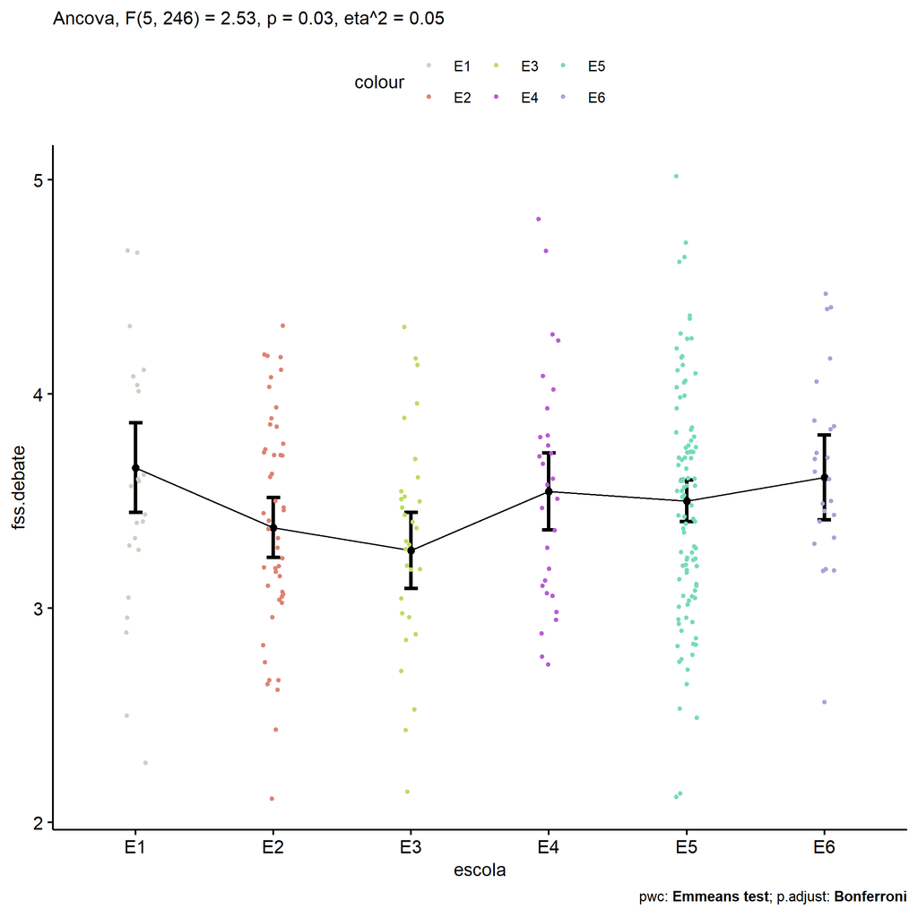

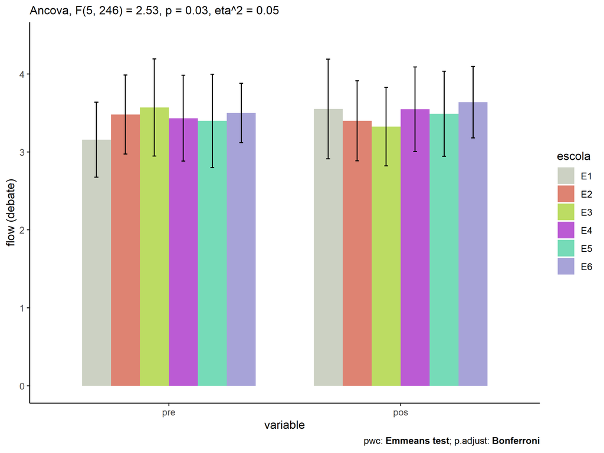

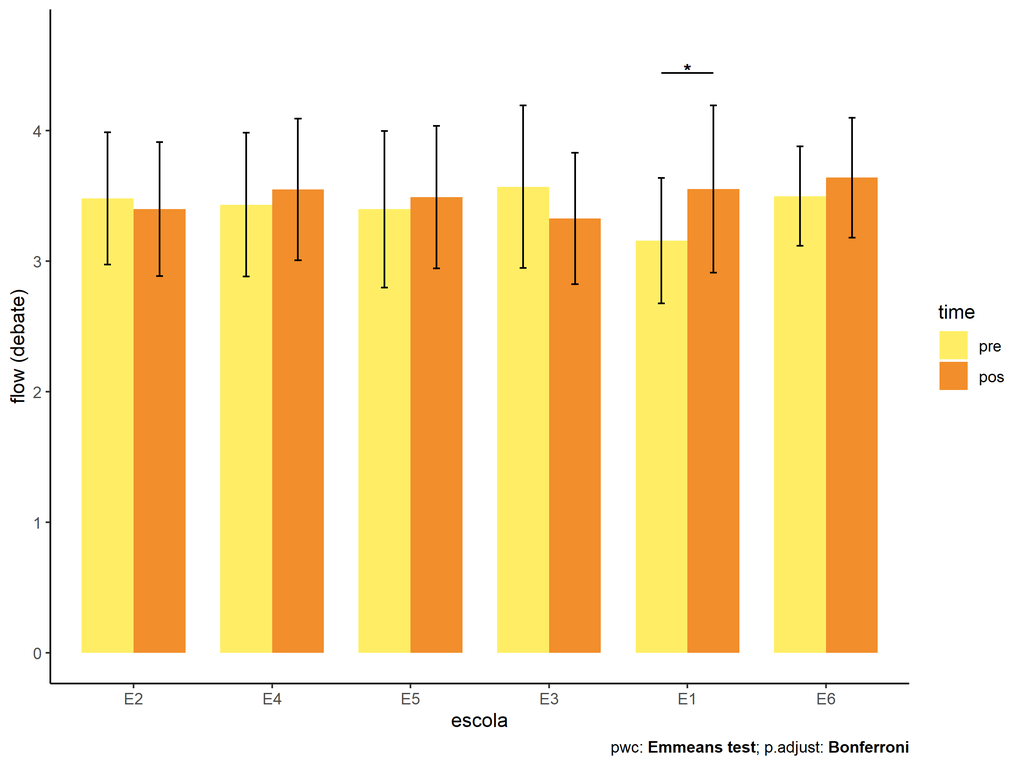

### factor: **zona.escola**

| var | zona.escola | n | M (pre) | SE (pre) | M (unadj) | SE (unadj) | M (adj) | SE (adj) |
| --- | --- | --- | --- | --- | --- | --- | --- | --- |
| fss.debate | Rural | 83 | 3.501 | 0.059 | 3.494 | 0.057 | 3.467 | 0.055 |
| fss.debate | Urbana | 170 | 3.390 | 0.043 | 3.472 | 0.042 | 3.485 | 0.038 |

| .y. | group1 | group2 | estimate | conf.low | conf.high | se | statistic | p | p.adj | p.adj.signif |
| --- | --- | --- | --- | --- | --- | --- | --- | --- | --- | --- |
| fss.debate | Urbana | Rural | 0.018 | -0.114 | 0.151 | 0.067 | 0.272 | 0.786 | 0.786 | ns |
| dfs.debate | Urbana | Rural | -0.110 | -0.257 | 0.036 | 0.074 | -1.484 | 0.139 | 0.139 | ns |

| .y. | zona.escola | group1 | group2 | estimate | conf.low | conf.high | se | statistic | p | p.adj | p.adj.signif |
| --- | --- | --- | --- | --- | --- | --- | --- | --- | --- | --- | --- |
| flow.debate | Urbana | pre | pos | -0.081 | -0.198 | 0.035 | 0.059 | -1.372 | 0.171 | 0.171 | ns |
| flow.debate | Rural | pre | pos | 0.007 | -0.160 | 0.174 | 0.085 | 0.081 | 0.936 | 0.936 | ns |

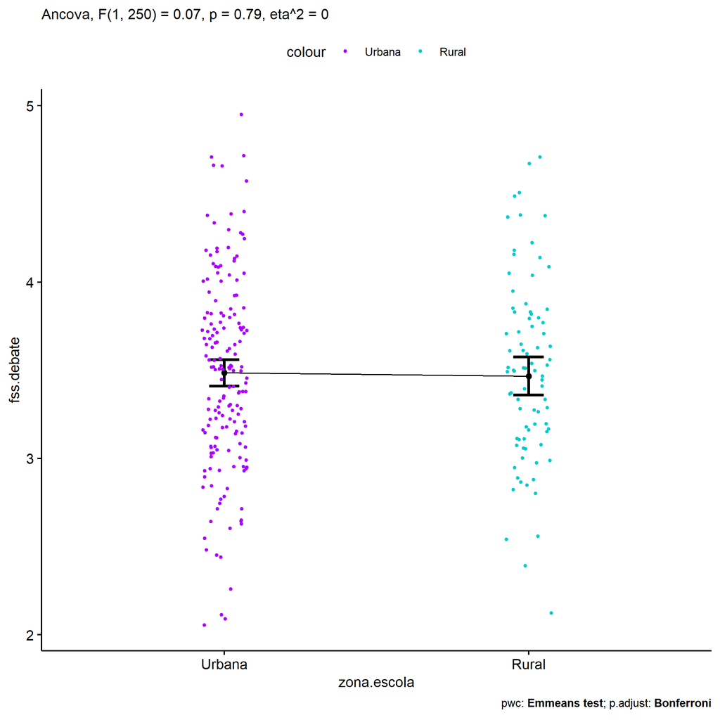

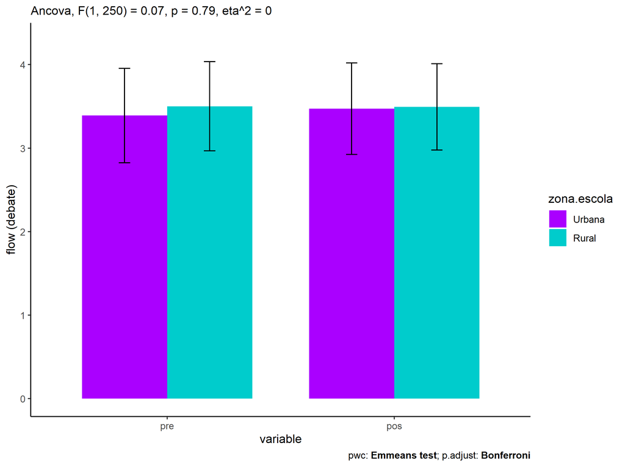

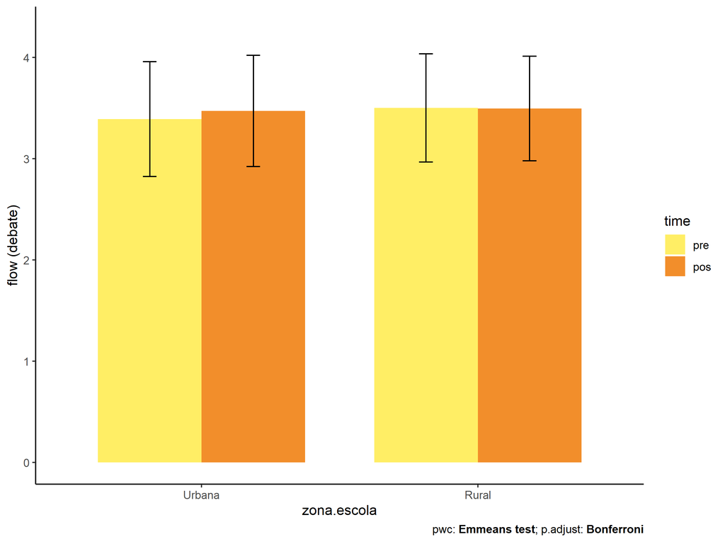